# Assignment Joan

Joan Oliveras Torra

2023-11-13

```r
library(sm)
data(aircraft)
attach(aircraft)
lgPower <- log(Power)
lgSpan <- log(Span)
lgLength <- log(Length)
lgWeight <- log(Weight)
lgSpeed <- log(Speed)
lgRange <- log(Range)
```

```r
source("locpolreg.R")
```

# First

We will use LOOCV for choosing the bandwidth parameter.

```r
h.cv.gcv <- function(x,y,h.v = exp(seq(log(diff(range(x))/20),
                                       log(diff(range(x))/4),l=10)),
                     p=1,type.kernel="normal"){
  n <- length(x)
  cv <- h.v*0
  gcv <- h.v*0
  for (i in (1:length(h.v))){
    h <- h.v[i]
    aux <- locpolreg(x=x,y=y,h=h,p=p,tg=x,
                     type.kernel=type.kernel, doing.plot=FALSE)
    S <- aux$S
    h.y <- aux$mtgr
    hii <- diag(S)
    av.hii <- mean(hii)
    cv[i] <- sum(((y-h.y)/(1-hii))^2)/n
    gcv[i] <- sum(((y-h.y)/(1-av.hii))^2)/n
  }
  return(list(h.v=h.v,cv=cv,gcv=gcv))
}
```

We find the optimal bandwidth using the LOOCV from the calculation defined in the previous function. We will use the default sequence of h.v. as vector of candidates.

```r
out.cv.gcv <- h.cv.gcv(x=Yr, y=lgWeight)

opt.h.cv<-out.cv.gcv$h.v[which.min(out.cv.gcv$cv)]
print(opt.h.cv)
```

```
## [1] 4.185346
```

This is the optimal bandwidth parameter:h according to LOOCV.

Next we fit a nonparametric regression to data. We will use q=1 (default).

```r
res1 <- locpolreg(x=Yr,y=lgWeight,h=opt.h.cv,q=1,r=0,main="q=1,h=Bandwidth found with LOOCV")
```

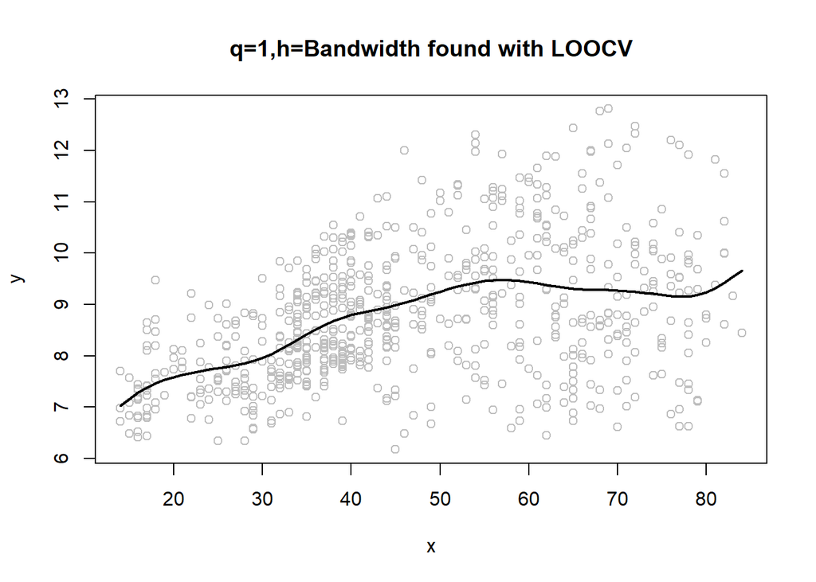

Now we proceed to calculate the estimated residuals $\hat\epsilon^2$ using the values $\hat m(x_i)$. We will use them later to plot the values. Using $log(\epsilon^2)$ we transform the estimated residuals into $z_i=log(\epsilon^2)$.

```r
epsilon.square <- (lgWeight - res1$mtgr)**2
z <- log(epsilon.square)
```

Next, we fit a nonparametric regression to data $(x_i, z_i)$. To do so, we will calculate again the best bandwidth using LOOCV and fit the new model with the updated best bandwidth.

```r
out.cv.gcv <- h.cv.gcv(x=Yr, y=z)

opt.h.cv2<-out.cv.gcv$h.v[which.min(out.cv.gcv$cv)]
print(opt.h.cv2)
```

```
## [1] 5.984916
```

```r
res2 <- locpolreg(x=Yr,y=z,h=opt.h.cv2,main="h=Bandwidth found with LOOCV")
```

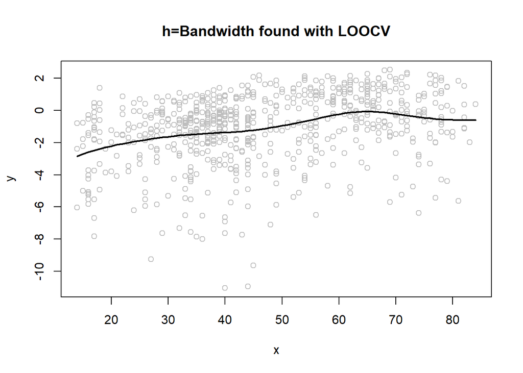

Finally, we estimate $\sigma^2(x)$, we draw graphic of $\hat\epsilon^2_i$ against $x_i$ with the estimated function $\sigma^2(x)$ and also plot the function $\hat m(x)$ with the bands $\hat m(x)+-1.96\hat\sigma(x)$.

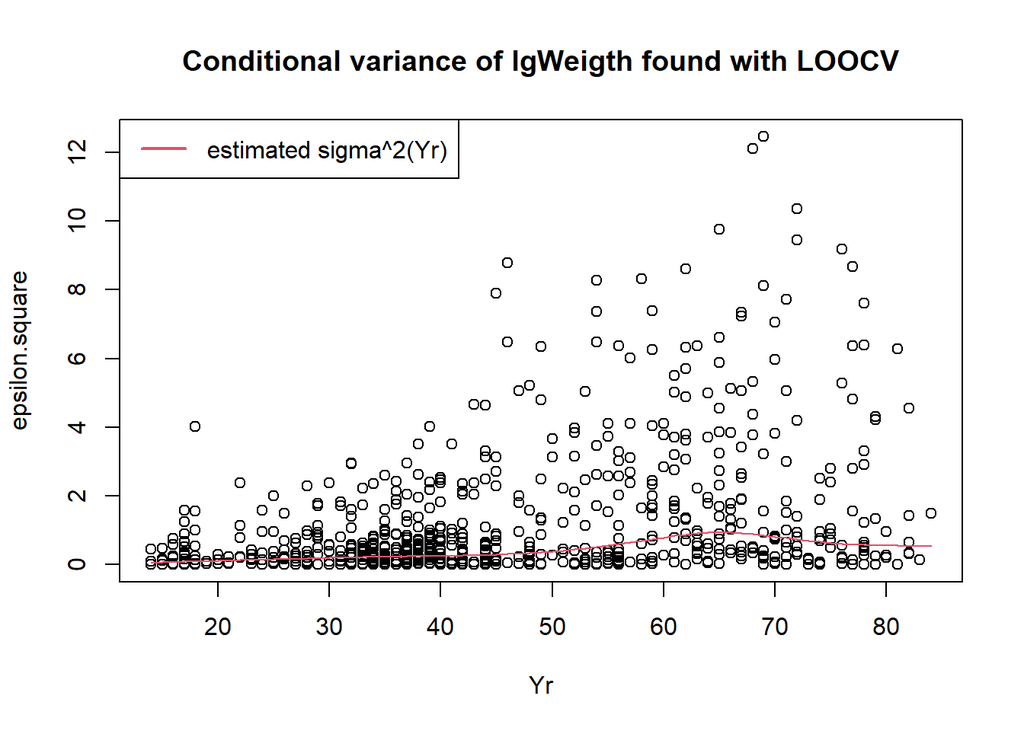

```r
sigma_squared=exp(res2$mtgr)

plot(Yr,epsilon.square, main="Conditional variance of lgWeigth found with LOOCV")
lines(Yr,sigma_squared,type="l",col=2)
legend("topleft",c("estimated sigma^2(Yr)"),col=c(2),lty=1,lwd=2)
```

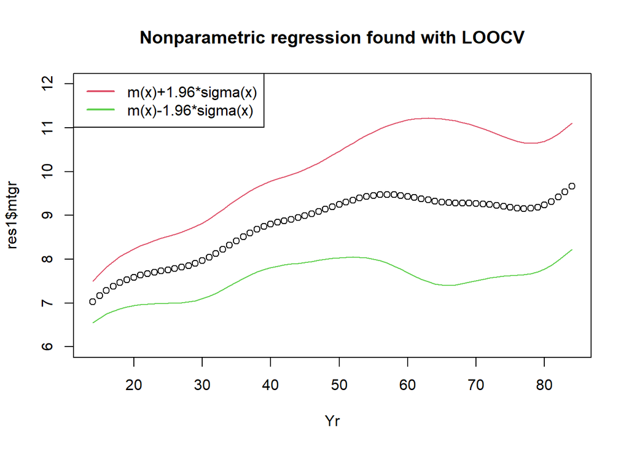

```r
plot(Yr, res1$mtgr, ylim = c(6, 12),main="Nonparametric regression found with LOOCV")
lines(Yr, res1$mtgr+1.96*sqrt(sigma_squared), type="l", col=2)
lines(Yr, res1$mtgr-1.96*sqrt(sigma_squared), type="l", col=3)
legend("topleft",c("m(x)+1.96*sigma(x)","m(x)-1.96*sigma(x)"),col=c(2, 3),lty=1,lwd=2)
```

# Second

Now we proceed to repeat the work with the second approach.

We will use the direct plug-in for choosing the bandwidth parameter, by using `dpill` function and `sm.regression` nonparametric regression to data.

```r
library(KernSmooth)
h.dpi <- dpill(x=Yr,y=lgWeight,range.x=range(Yr))
print(h.dpi)
```

```
## [1] 5.54261
```

```r
sm_1<-sm.regression(x=Yr,y=lgWeight,h=h.dpi,col=2, eval.points = Yr)
```

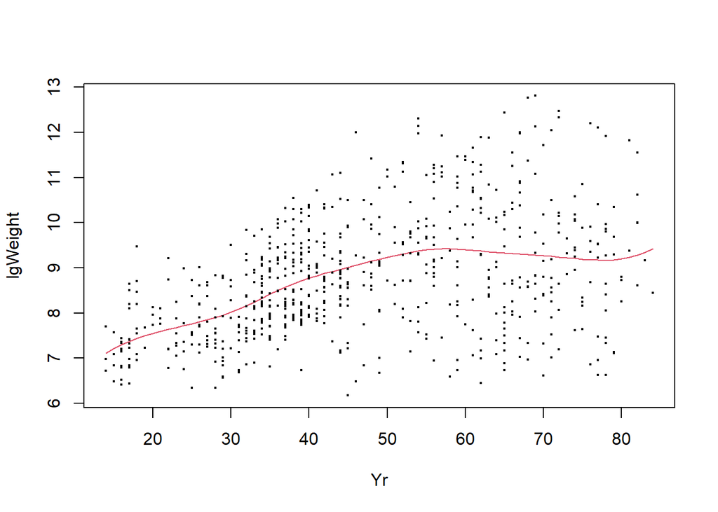

Now we proceed to calculate the estimated residuals $\hat\epsilon^2$ using the values $\hat m(x_i)$. We will use them later to plot the values. Using $log(\epsilon^2)$ we transform the estimated residuals into $z_i=log(\epsilon^2)$.

```r
epsilon.square2 <- (lgWeight - sm_1$estimate)**2
z2 <- log(epsilon.square2)
```

Next, we fit a nonparametric regression to data $(x_i, z_i)$. To do so, we will calculate again the best bandwidth using the direct plug-in and then fit the new model with the updated best bandwidth.

```r
h.dpi2 <- dpill(x=Yr,y=z2,range.x=range(Yr))
print(h.dpi2)
```

```
## [1] 3.948975
```

```r
sm_2<-sm.regression(x=Yr,y=z2,h=h.dpi2,col=2, eval.points = Yr)
```

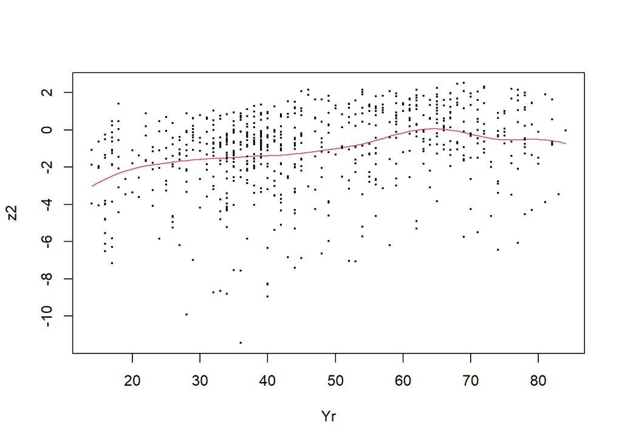

Finally, we estimate $\sigma^2(x)$, we draw graphic of $\hat\epsilon^2_i$ against $x_i$ with the estimated function $\sigma^2(x)$ and also plot the function $\hat m(x)$ with the bands $\hat m(x)+-1.96\hat\sigma(x)$.

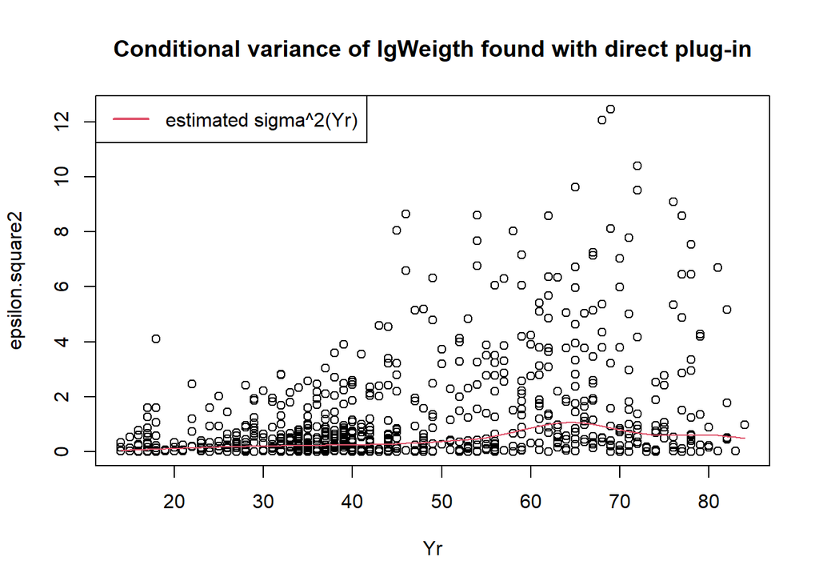

```r
sigma_squared2=exp(sm_2$estimate)

plot(Yr,epsilon.square2, main="Conditional variance of lgWeigth found with direct plug-in")
lines(Yr,sigma_squared2,type="l",col=2)
legend("topleft",c("estimated sigma^2(Yr)"),col=c(2),lty=1,lwd=2)
```

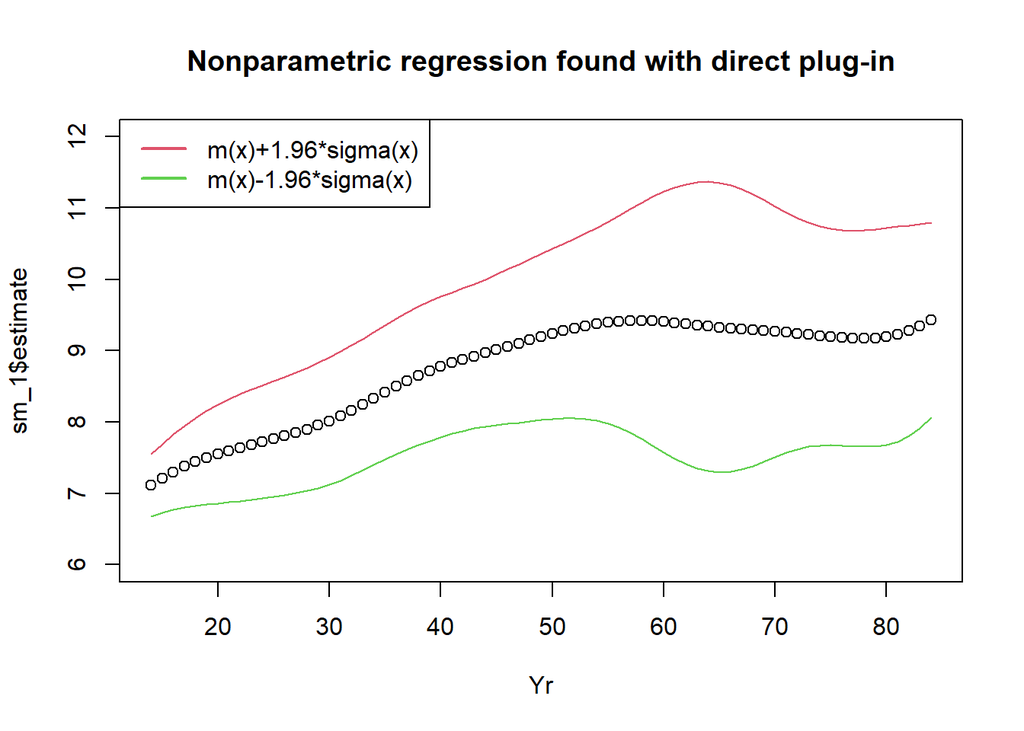

```r
plot(Yr, sm_1$estimate, ylim = c(6, 12),main="Nonparametric regression found with direct plug-in")
lines(Yr, sm_1$estimate+1.96*sqrt(sigma_squared2), type="l", col=2)
lines(Yr, sm_1$estimate-1.96*sqrt(sigma_squared2), type="l", col=3)
legend("topleft",c("m(x)+1.96*sigma(x)","m(x)-1.96*sigma(x)"),col=c(2, 3),lty=1,lwd=2)
```

As we see, both plots seem to be very similar when using LOOCV or the direct plug-in from library KernSmooth.